# All Stars - Moneyball

Devansh Saxena

July 14, 2018

## Background

During the 2001-02 offseason the Oakland A’s team lost three key players to teams with larger revenues.

The goal of this project is to look at player and salary data for those years to find players of the same calibre (statistically) who have been under valued by the market and thus are suitable low salary replacements. We’ll be looking at data about teams in Major League Baseball. A couple of important points:

-> Major League Baseball is a professional baseball league, where teams pay players to play baseball.

-> The goal of each team is to win as many games out of a 162 game season as possible.

-> Teams win games by scoring more runs than their adversary.

-> In principle, better players are costlier, so teams that want good players need to spend more money.

-> Teams that spend the most, frequently win the most.

## Introduction

This project is based off the book written by Michael Lewis (later turned into a movie). The central theory of book Moneyball is that (this paragraph is taken from the Book Moneyball) the collective wisdom of baseball insiders over the past century is subjective and often flawed. Statistics such as stolen bases, batted runs, and batting average, typically used to gauge players. The book argues that the Oakland A’s front office took advantage of more analytical gauges of player performance to field a team that could better compete against richer competitors in Major League Baseball (MLB). Rigorous statistical analysis had demonstrated that on-base percentage and slugging percentage are better indicators of offensive success and the A’s became convinced that these qualities were cheaper to obtain on the open market than more historically valued qualities such as speed and contact. These observations often flew in the face of conventional baseball wisdom and the beliefs of many baseball executives. Because of the team’s smaller revenues, Oakland A is forced to find players undervalued by the market and their system for finding value in undervalued players has proven itself thus far. This approach brought the A’s to the playoffs in 2002 and 2003.

In this project we’ll work with some data and with the goal of trying to find replacement players for the ones lost at the start of the off-season during the 2001–02 offseason, the team lost three key players to larger market teams: Jason Giambi to the New York Yankees, Johnny Damon to the Boston Red Sox, and Jason Isringhausen to the St. Louis Cardinals.

## Source of DATA

I am using data from Sean Lahaman’s Website a very useful source for baseball statistics.

## Reading the data

I already have Batting.csv and Salaries.csv in my current working directory.

```r
batting <- read.csv("Batting.csv")
sal <- read.csv("Salaries.csv")
```

## Adding 3 more statistics in the Batting.csv data

1. Batting Average (BA)
2. On base percentage (OBP)
3. Slugging percentage (SLP) These statistics or we can say columns were not present in the data set but we’ll need them to predict our players.

```r
batting$BA <- batting$H / batting$AB
tail(batting$BA)
```

```
## [1] 0.0000000 0.1230769 0.2746479 0.1470588 0.2745098 0.2138728
```

```r
batting$OBP <- (batting$H + batting$BB + batting$HBP) / (batting$AB + batting$BB + batting$HBP + batting$SF)
```

For Calculating Slugging percentage (SLP) first we need to calculate the singles i.e. X1B

```r
batting$X1B <- batting$H - batting$X2B - batting$X3B - batting$HR
batting$SLP <- ((1*batting$X1B) + (2*batting$X2B) + (3*batting$X3B) + (4*batting$HR)) / batting$AB
str(batting)
```

```
## 'data.frame':    97889 obs. of  28 variables:
##  $ playerID : Factor w/ 18107 levels "aardsda01","aaronha01",..: 1 1 1 1 1 1 1 2 2 2 ...
##  $ yearID   : int  2004 2006 2007 2008 2009 2010 2012 1954 1955 1956 ...
##  $ stint    : int  1 1 1 1 1 1 1 1 1 1 ...
##  $ teamID   : Factor w/ 149 levels "ALT","ANA","ARI",..: 117 35 33 16 116 116 93 80 80 80 ...
##  $ lgID     : Factor w/ 6 levels "AA","AL","FL",..: 4 4 2 2 2 2 2 4 4 4 ...
##  $ G        : int  11 45 25 47 73 53 1 122 153 153 ...
##  $ G_batting: int  11 43 2 5 3 4 NA 122 153 153 ...
##  $ AB       : int  0 2 0 1 0 0 NA 468 602 609 ...
##  $ R        : int  0 0 0 0 0 0 NA 58 105 106 ...
##  $ H        : int  0 0 0 0 0 0 NA 131 189 200 ...
##  $ X2B      : int  0 0 0 0 0 0 NA 27 37 34 ...
##  $ X3B      : int  0 0 0 0 0 0 NA 6 9 14 ...
##  $ HR       : int  0 0 0 0 0 0 NA 13 27 26 ...
##  $ RBI      : int  0 0 0 0 0 0 NA 69 106 92 ...
##  $ SB       : int  0 0 0 0 0 0 NA 2 3 2 ...
##  $ CS       : int  0 0 0 0 0 0 NA 2 1 4 ...
##  $ BB       : int  0 0 0 0 0 0 NA 28 49 37 ...
##  $ SO       : int  0 0 0 1 0 0 NA 39 61 54 ...
##  $ IBB      : int  0 0 0 0 0 0 NA NA 5 6 ...
##  $ HBP      : int  0 0 0 0 0 0 NA 3 3 2 ...
##  $ SH       : int  0 1 0 0 0 0 NA 6 7 5 ...
##  $ SF       : int  0 0 0 0 0 0 NA 4 4 7 ...
##  $ GIDP     : int  0 0 0 0 0 0 NA 13 20 21 ...
##  $ G_old    : int  11 45 2 5 NA NA NA 122 153 153 ...
##  $ BA       : num  NaN 0 NaN 0 NaN ...
##  $ OBP      : num  NaN 0 NaN 0 NaN ...
##  $ X1B      : int  0 0 0 0 0 0 NA 85 116 126 ...
##  $ SLP      : num  NaN 0 NaN 0 NaN ...
```

## Merging the two data sets

Now we’ll merge the two data sets i.e. merging Salaries.csv with Batting.csv. When we display the summary of batting data we’ll see in yearID that it starts from 1871 and goes onn till 2013. But we don’t require such old data. Therefore we’ll subset it and make it start from 1985.

```r
batting <- subset(batting,yearID >= 1985)
combo <- merge(batting,sal,by = c('playerID','yearID'))
```

## Analyzing lost players

We’ll need the stats of lost players so that we can find the required replacements.

```r
lost_players <- subset(combo,playerID %in% c('giambja01','damonjo01','saenzol01'))
lost_players
```

```
##        playerID yearID stint teamID.x lgID.x   G G_batting  AB   R   H X2B
## 5135  damonjo01   1995     1      KCA     AL  47        47 188  32  53  11
## 5136  damonjo01   1996     1      KCA     AL 145       145 517  61 140  22
## 5137  damonjo01   1997     1      KCA     AL 146       146 472  70 130  12
## 5138  damonjo01   1998     1      KCA     AL 161       161 642 104 178  30
## 5139  damonjo01   1999     1      KCA     AL 145       145 583 101 179  39
## 5140  damonjo01   2000     1      KCA     AL 159       159 655 136 214  42
## 5141  damonjo01   2001     1      OAK     AL 155       155 644 108 165  34
## 5142  damonjo01   2002     1      BOS     AL 154       154 623 118 178  34
## 5143  damonjo01   2003     1      BOS     AL 145       145 608 103 166  32
## 5144  damonjo01   2004     1      BOS     AL 150       150 621 123 189  35
## 5145  damonjo01   2005     1      BOS     AL 148       148 624 117 197  35
## 5146  damonjo01   2006     1      NYA     AL 149       149 593 115 169  35
## 5147  damonjo01   2007     1      NYA     AL 141       141 533  93 144  27
## 5148  damonjo01   2008     1      NYA     AL 143       143 555  95 168  27
```

[output cut: 120 more lines]

Here you can see that in 2001 these players were in OAK and in 2002 they changed there teams and went in some anothere team. Now, we want the information (stats) just for the year 2001 and also we need only some of the columns to analyze.

```r
lost_players <- lost_players <- subset(lost_players,yearID == 2001)
lost_players <- lost_players[, c('playerID','H','X1B','X2B','X3B','HR','OBP','SLP','BA','AB')]
head(lost_players)
```

```
##        playerID   H X1B X2B X3B HR       OBP       SLP        BA  AB
## 5141  damonjo01 165 118  34   4  9 0.3235294 0.3633540 0.2562112 644
## 7878  giambja01 178  91  47   2 38 0.4769001 0.6596154 0.3423077 520
## 20114 saenzol01  67  36  21   1  9 0.2911765 0.3836066 0.2196721 305
```

We have the required data of the lost players and now we have to find the replacement players “The Most Under Valued Players”

## The 3 major constraints

In finding the replacement players we had 3 major constraints:-

1. Total combine salary should not exceed 15 million dollars.
2. Combine number of At Bats (AB) should be greater than or equal to the combine At Bats (AB) of lost players. In this case it’ll be >= 1469.
3. The mean OBP of replacement players should be greater than or equal to the mean OBP of lost players. In this case it’ll be >= 0.364

```r
combo <- subset(combo,yearID == 2001)
str(combo)
```

```
## 'data.frame':    915 obs. of  31 variables:
##  $ playerID : Factor w/ 18107 levels "aardsda01","aaronha01",..: 14 16 19 34 86 108 167 168 170 179 ...
##  $ yearID   : int  2001 2001 2001 2001 2001 2001 2001 2001 2001 2001 ...
##  $ stint    : int  1 1 1 1 1 1 1 1 1 1 ...
##  $ teamID.x : Factor w/ 149 levels "ALT","ANA","ARI",..: 55 4 116 102 72 94 55 94 66 79 ...
##  $ lgID.x   : Factor w/ 6 levels "AA","AL","FL",..: 4 4 2 4 4 4 4 4 2 2 ...
##  $ G        : int  28 6 28 162 43 91 58 124 113 57 ...
##  $ G_batting: int  28 6 2 162 41 91 54 124 113 57 ...
##  $ AB       : int  42 9 4 588 39 296 0 457 387 175 ...
##  $ R        : int  5 0 0 118 2 28 0 64 44 20 ...
##  $ H        : int  11 2 1 170 2 82 0 111 106 46 ...
##  $ X2B      : int  3 0 0 48 1 14 0 22 16 13 ...
##  $ X3B      : int  0 0 0 4 0 2 0 0 4 2 ...
##  $ HR       : int  0 0 0 31 0 6 0 17 4 4 ...
##  $ RBI      : int  5 0 0 110 1 27 0 49 32 20 ...
```

[output cut: 17 more lines]

We can see at the top of the above output that there are total 915 observations (obs) i.e. we have total 915 players out of which we have to find our 3 most under valued players who can fullfil our constraints.

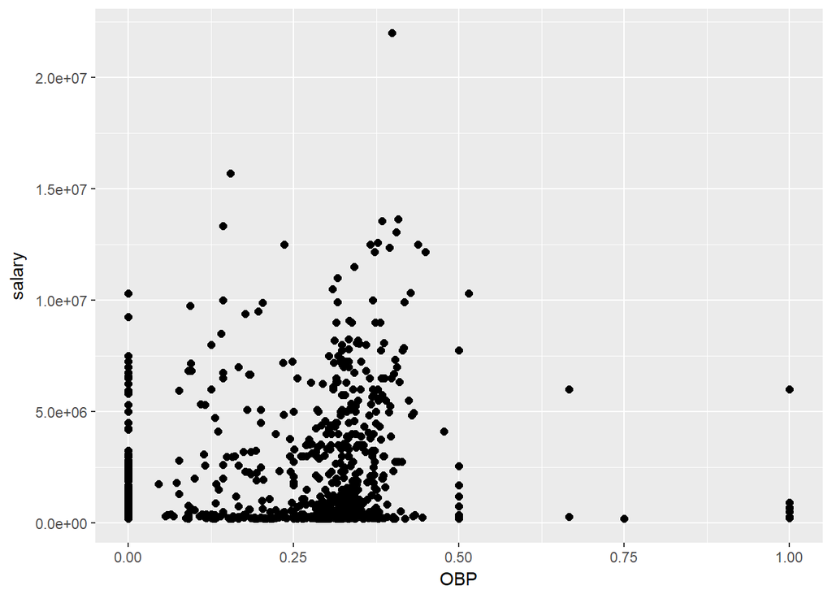

```r
library(ggplot2)
ggplot(combo, aes(x = OBP, y = salary)) + geom_point(size=2)
```

After looking at the scatter plot we can see that there are tons of points on 0.00 OBP, little at 0.50 OBP and some at 1.00 OBP. OBP means the percentage of time a player spends on base. 1.00 means 100% 0.50 means 50% 0.00 means 0% We want average OBP equal to 0.36 and there are lots of options of OBP = 0.36 and also salary of those options are under 10 million dollars. If we have a closer look we can see that even below 8 million dollars we have lots of options.

```r
combo <- subset(combo,salary < 8000000 & OBP > 0)
str(combo)
```

```
## 'data.frame':    602 obs. of  31 variables:
##  $ playerID : Factor w/ 18107 levels "aardsda01","aaronha01",..: 14 16 19 34 86 108 168 170 179 228 ...
##  $ yearID   : int  2001 2001 2001 2001 2001 2001 2001 2001 2001 2001 ...
##  $ stint    : int  1 1 1 1 1 1 1 1 1 1 ...
##  $ teamID.x : Factor w/ 149 levels "ALT","ANA","ARI",..: 55 4 116 102 72 94 94 66 79 45 ...
##  $ lgID.x   : Factor w/ 6 levels "AA","AL","FL",..: 4 4 2 4 4 4 4 2 2 2 ...
##  $ G        : int  28 6 28 162 43 91 124 113 57 157 ...
##  $ G_batting: int  28 6 2 162 41 91 124 113 57 157 ...
##  $ AB       : int  42 9 4 588 39 296 457 387 175 575 ...
##  $ R        : int  5 0 0 118 2 28 64 44 20 113 ...
##  $ H        : int  11 2 1 170 2 82 111 106 46 193 ...
##  $ X2B      : int  3 0 0 48 1 14 22 16 13 34 ...
##  $ X3B      : int  0 0 0 4 0 2 0 4 2 12 ...
##  $ HR       : int  0 0 0 31 0 6 17 4 4 20 ...
##  $ RBI      : int  5 0 0 110 1 27 49 32 20 100 ...
```

[output cut: 17 more lines]

If we go up and see (in the above output) we have only 602 obs left. Now, 1469 should be the sum of AB of 3 replacement players. Therefore each player should have AB = 1496/3 i.e. 489.66 AB

```r
combo <- subset(combo,AB >= 450)
str(combo)
```

```
## 'data.frame':    122 obs. of  31 variables:
##  $ playerID : Factor w/ 18107 levels "aardsda01","aaronha01",..: 34 168 228 235 303 319 488 554 778 1020 ...
##  $ yearID   : int  2001 2001 2001 2001 2001 2001 2001 2001 2001 2001 ...
##  $ stint    : int  1 1 1 1 1 1 1 1 1 1 ...
##  $ teamID.x : Factor w/ 149 levels "ALT","ANA","ARI",..: 102 94 45 58 2 102 117 58 86 116 ...
##  $ lgID.x   : Factor w/ 6 levels "AA","AL","FL",..: 4 4 2 4 2 4 4 4 4 2 ...
##  $ G        : int  162 124 157 136 161 147 156 161 132 135 ...
##  $ G_batting: int  162 124 157 136 161 147 156 161 132 135 ...
##  $ AB       : int  588 457 575 513 672 522 636 600 472 470 ...
##  $ R        : int  118 64 113 79 83 69 114 126 42 62 ...
##  $ H        : int  170 111 193 170 194 153 206 173 118 122 ...
##  $ X2B      : int  48 22 34 31 39 30 37 43 33 28 ...
##  $ X3B      : int  4 0 12 1 2 2 5 4 2 0 ...
##  $ HR       : int  31 17 20 27 28 11 37 39 6 15 ...
##  $ RBI      : int  110 49 100 108 123 61 97 130 38 64 ...
```

[output cut: 17 more lines]

Now if we go up and see (in the above output) we are left with only 122 obs. Now we’ll arrange it according to OBP in descending order and we need only 10 obs as the OBP is ordered in descending order.

```r
library(dplyr)
options <- head(arrange(combo,desc(OBP)),10)
```

Now we need only some selected columns to choose our replacement players.

```r
options[,c('playerID','AB','salary','OBP')]
```

```
##     playerID  AB  salary       OBP
## 1  giambja01 520 4103333 0.4769001
## 2  heltoto01 587 4950000 0.4316547
## 3  berkmla01 577  305000 0.4302326
## 4  gonzalu01 609 4833333 0.4285714
## 5  martied01 470 5500000 0.4234079
## 6  thomeji01 526 7875000 0.4161491
## 7  alomaro01 575 7750000 0.4146707
## 8  edmonji01 500 6333333 0.4102142
## 9  gilesbr02 576 7333333 0.4035608
## 10 pujolal01 590  200000 0.4029630
```

Here we’ll get couple of players out of which we have to choose our Best Under Valued Players, we can’t choose the first one as he is one of the lost player.

## Result

Now if we look at the above output closely we can see that the 2nd, 3rd and 4th player fullfil our requirments completely i.e.

-> salary is something around 10 million dollars.

-> Mean OBP is even greater than the Mean OBP of lost players i.e. 0.429

-> AB is also greater than the AB of lost players i.e. 1773.

## Conclusion

We got our Best Under Valued replacement players and even better than the lost players.